# ANALISIS DE VENTAS

AUGUSTO ALARCON

8/3/2021

[figure not shown]

[figure not shown]

e-mail: augustoludwing@hotmail.com

## Grupo KBL Bolivia

La compañia en estudio comercializa medicamentos para patologias oncologicas, los productos que maneja la empresa representas costos elevados por lo que la **gestion eficiente del inventario** es un punto critico en los procesos dentro de la empresa.

La empresa atraviesa problemas de desabastecimiento y sobrestock que ocaciona vencimiento de productos, ambos casos en casos particulares de productos. Para el analisis presente utilizaremos de ejemplo un producto de consumo recurrente y otro producto de consumo irregular, hacemos la diferenciacion para mostrar los diferentes comportamientos.

# REFERENCIAS DE POSIBLES SOLUCIONES

**Diseño de un plan de gestión de inventario para mejorar las ventas de mercaderías en una empresa comercializadora de medicamentos** *JJ Pérez Samaniego, MA Cruces Najarro - 2019* http://168.121.49.87/handle/URP/3114

**Análisis y Evaluación del Sistema de Gestión de Inventario de Medicamentos Antirretrovirales en el Consejo Presidencial del SIDA (COPRESIDA)** *LE Ortega, P Julnes, P Ortega - 2015* http://bibliotecajuanbosch.org/wp-content/uploads/iglobal/tesis/ADP/ADP%20514%20TESIS%20L.%20ORTEGA%2010-0138.PDF

**Descripción del proceso de Implementación del Sistema de Inventario Computarizado “Farmasis” en la Botica Unifarma, Lima–2020.** *JB Medina García, SZ Tapia Huillcara - 2020 - repositorio.upeu.edu.pe* https://repositorio.upeu.edu.pe/handle/UPEU/3950

## DATOS - PRODUCTO DE CONSUMO REGULAR

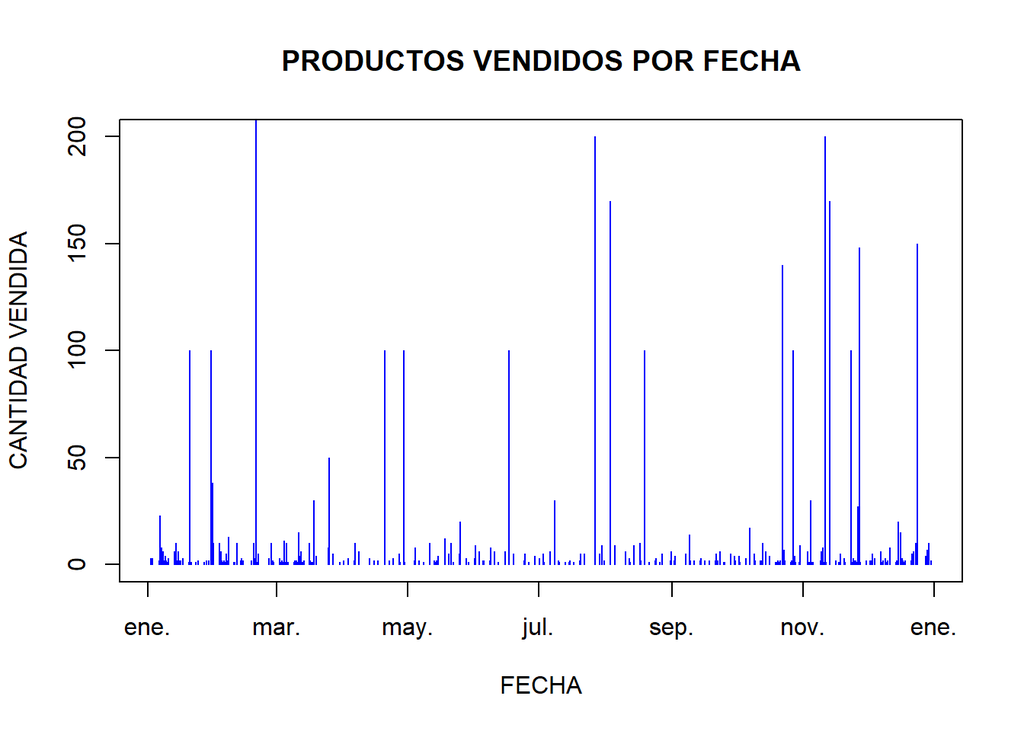

```r
library(readxl)
DATOS <- read_excel("C:/Users/Augusto/Downloads/TRABAJO R STUDIO/DATOS.xlsx",
    sheet = "RES_CICLO", col_types = c("date",
        "text", "numeric"))
View(DATOS)
plot(DATOS$Fecha,DATOS$`Suma de Cantidad`,type = "h",ylim = c(0,200),ylab = "CANTIDAD VENDIDA",xlab = "FECHA",main = "PRODUCTOS VENDIDOS POR FECHA",col="blue")
```

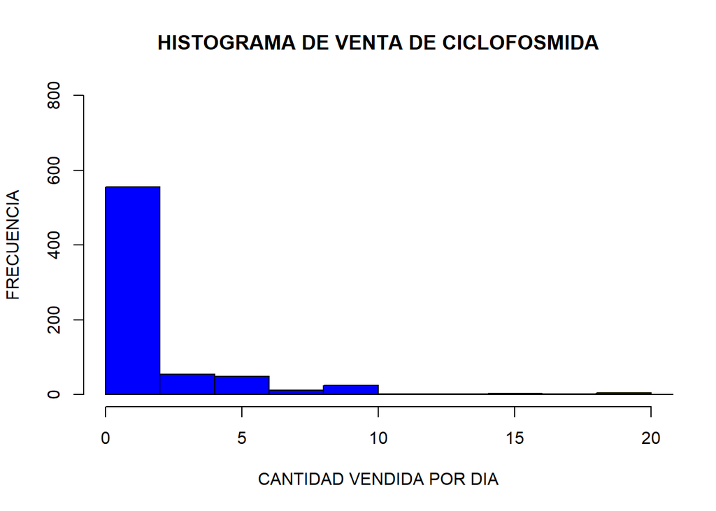

```r
hist(DATOS$`Suma de Cantidad`,breaks=500,xlim = c(0,20),ylim = c(0,800),main = "HISTOGRAMA DE VENTA DE CICLOFOSMIDA",xlab = "CANTIDAD VENDIDA POR DIA",ylab = "FRECUENCIA",col = "blue",freq = TRUE,axes = TRUE)
```

## DATOS - PRODUCTO DE CONSUMO IRREGULAR

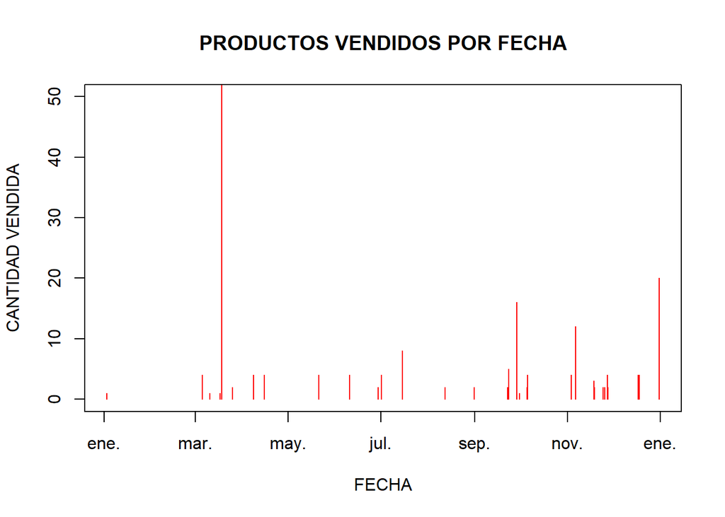

```r
library(readxl)
DATOS1 <- read_excel("C:/Users/Augusto/Downloads/TRABAJO R STUDIO/DATOS.xlsx",
    sheet = "RES_BOZO", col_types = c("date",
        "text", "numeric"))
View(DATOS1)
plot(DATOS1$Fecha,DATOS1$`Suma de Cantidad`,type = "h",ylim = c(0,50),ylab = "CANTIDAD VENDIDA",xlab = "FECHA",main = "PRODUCTOS VENDIDOS POR FECHA",col="red")
```

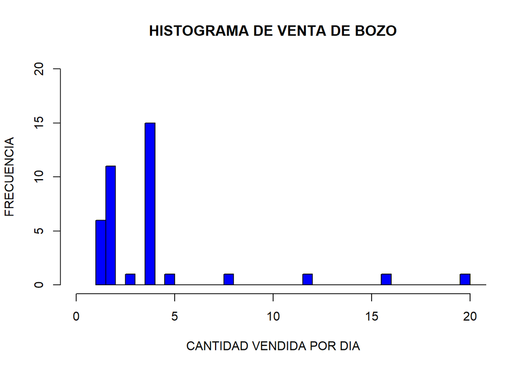

```r
hist(DATOS1$`Suma de Cantidad`,breaks=100,xlim = c(0,20),ylim = c(0,20),main = "HISTOGRAMA DE VENTA DE BOZO",xlab = "CANTIDAD VENDIDA POR DIA",ylab = "FRECUENCIA",col = "blue",freq = TRUE,axes = TRUE)
```